# Post Lab Exercises Week 6 NLS Key

## Set up

Create your own quarto document to answer these questions. Attach all necessary packages and load the lizard data from the lab’s data folder `here("data","lizards.csv")` Complete at least the first lizard nls model in lab and show either Casey or Nathan before you leave.

## Purrr Practice

1. What data type do the following functions return?
- `map()`
- `map_chr()`
- `map_dbl()`
- `map_df()`
- `map_lgl()`

Map returns a list, map_chr returns characters, map_dbl returns numeric double values (with decimals), map_df returns a dataframe, and map_lgl returns TRUE/FALSE logical values.

2. If I have a dataset where I want to iterate over 4 different variables that are changing, which of the following functions would I use?
1. `map()`
2. `map2()`
3. `pmap()`
4. `mutate()`

pmap would be the best because we can define a list of 4 changing variables. For example, we want to sum up four variables that are changing we would use pmap on the list. Notice the names are consistent so that x goes where the x input is and so forth for each one.

```r
library(tidyverse)
sum_fcn <- function(x, y, z,b) {
  # do something with a, b, and c
  return(x + y + z+b)
}
pmap(.l=list(x=seq(1,5),y=seq(2,6),z=seq(3,7),b=seq(4,8)),sum_fcn)
```

```
[[1]]
[1] 10

[[2]]
[1] 14

[[3]]
[1] 18

[[4]]
[1] 22

[[5]]
[1] 26
```

3. Format the out of order code into the correct order for it to run

```r
library(gapminder)
output <- gapminder |>
  janitor::clean_names() |>
  nest(.by=continent) |>
  mutate(reg=map(.x=data, ~lm(life_exp~pop+gdp_percap+year,data=.x))) |>
  mutate(coeff=map(.x=reg, ~coefficients(.x)))
```

4. Generate 10 random samples from a normal distribution where the mean and standard deviation increase from 1 to 10 and 2 to 20. Hint: Make sure the sequences are of the same length by setting the length.out=11 argument in seq()

```r
mean_in<-seq(1,10,length.out=11)
sd_in<-seq(2,20,length.out=11)

map2(mean_in,sd_in,~rnorm(n=10,mean=.x,sd=.y))
```

```
[[1]]
 [1] -1.5009459  1.3569030 -1.4897694  3.7343874 -1.5020015  0.3517126
 [7]  2.8445825  0.4651380 -0.3777302  4.1834317

[[2]]
 [1]  2.1211656  6.6282380  8.3021676  5.2703783  5.5566359 -0.6811961
 [7]  3.2235775 -1.6064379  1.0519781 -2.5738717

[[3]]
 [1]  0.2018081  5.0822333  3.0174839  1.3376665  2.6213425  1.0110118
 [7]  4.1676296 12.5589887  6.2971834  1.6089586

[[4]]
 [1]  0.7216415 -0.5860280  2.4936855 -6.8301555  1.8918584  0.4843066
 [7] -0.2557383  3.2727452 -0.6481461 -0.9881026

[[5]]
 [1]  7.338186  8.719865 -5.510643 12.707115 29.000453 -4.704032 -6.403165
 [8] 12.350815 -2.393013  4.574700

[[6]]
 [1] 18.704393 15.065311  7.241175  8.168967 12.090551 -6.301008 -1.610955
 [8]  9.114799 20.512032 17.512594

[[7]]
 [1] 20.5334577 -0.8217843  6.4633403 10.1873295  5.4043541  6.6535398
 [7] 19.7831811 12.2765103 29.3023277  5.8095168

[[8]]
 [1] -10.339856  -8.148171   3.080295   5.817455  16.940076   2.882251
 [7]  13.633230   1.053288 -18.731257  23.209840

[[9]]
 [1]   9.9344229  15.6888663  -0.7115615  16.3868983  -2.0391238 -14.7091917
 [7]   7.1601207   7.4055939  24.2534258  32.0087686

[[10]]
 [1]  27.16718186  32.66594876  13.35760845  21.97227025  35.88614409
 [6]  25.56934651  -4.98326171 -20.20397290   0.02891644  15.61799526

[[11]]
 [1] -24.6782700  59.8123701   0.1016798   0.1917642  16.5682728 -31.4792786
 [7]  -1.1868756  18.4016075 -18.5222278  10.2008357
```

5. Use purrr to quickly return the class of every column from the `gapminder` dataset as characters

```r
gapminder |> map_chr(class)
```

```
  country continent      year   lifeExp       pop gdpPercap
 "factor"  "factor" "integer" "numeric" "integer" "numeric"
```

## NLS Practice

Source: Lightfoot, D. and W.G. Whitford. 2020. Lizard pitfall trap data from 11 NPP study locations at the Jornada Basin LTER site, 1989-2006 ver 37. Environmental Data Initiative. https://doi.org/10.6073/pasta/4a6e258fb49c31e222ecbbcfd128967f

Now you will use non linear least squares to estimate parameters of a length to weight model for lizard populations in New Mexico. Scientists measure from the tip of the nose to the very beginning of their tail in a metric called Snout-to-Vent Length (SVL). Lizards can eject their tails in defense against predators. Some adult lizards do not have tails so total length is not a very useful measurement. We find estimates of their weight and fecundity for a population model by using NLS to parameterize a weight to length model.

[Example of a lizard’s snout to vent length measurement.](https://www.researchgate.net/profile/Andre-Koch-2/publication/341568459/figure/fig1/AS:893936419733504@1590142459151/The-Total-length-TL-is-given-by-the-Snout-vent-length-SVL-and-the-tail-length-Also.png)

1. Create a dataframe called `lizard_clean` of only the sex, species, snout to vent length, and weight. Exclude juveniles from the analysis. Remove any species that possess less than 6 observations. We need to balance the data between males and females i.e. make sure that all species have both males and females. Run this code to do that:

```r
lizard <- read_csv(here::here("data","lizard.csv"))

lizard_clean<-lizard |>
  select(spp,sex,SV_length,weight) |>
  filter(sex!="J") |>
  drop_na() |>
  group_by(spp,sex) |>
  filter(n()>=6)

lizard_m<-lizard_clean |>
  filter(sex=="M")

lizard_f<-lizard_clean |>
  filter(sex=="F")

spp_select<-intersect(unique(lizard_m$spp),unique((lizard_f$spp)))

lizard_comb<-lizard_clean |>
  filter(spp %in% spp_select)
```

Use the data frame `lizard_comb` for the following analyses

2. Fit a snout length to weight model of the following form to all lizard in your clean dataframe.

$$\begin{equation}
W=a(SVL)^b
\end{equation}$$

1. Weight is given by W, snout to vent length by SVL, and a and b are the parameters that need to be fitted. Which strategy would be best to provide an initial guess? We could go with strategy one and look through the literature, but let’s practice our coding and math skills.
2. Since we know the model is exponential in nature, we could log transform the data. If we do a standard OLS regression on the log transformed data, we can get approximations of the parameters from the regression coefficients `my_guess_model <- lm(log_weight ~ log_length, data = my_df)`
3. Using the coefficients function, we can then supply the nls start list with the regression coefficients. You will have to mathematically transform the intercept coefficient to get the guess for parameter a. With a= exp(coefficients(guess_model))[1]. The following math breaks down why that works.
   $$\begin{equation}
   \begin{aligned}
   W&=a(SVL)^b \\
   \ln{W}&=\ln{a}+b\ln{(SVL)} &\text{Take logs} \\
   \hat{\ln{W}}&=\hat{a}+\hat{b}\ln{(SVL)} &\text{Run regression to get coefficients}\\
   \hat{a}&=\ln{a} &\text{Estimated a from Regression}\\
   a&=e^{\hat{a}} &\text{Convert back to original a in model}
   \end{aligned}
   \end{equation}$$

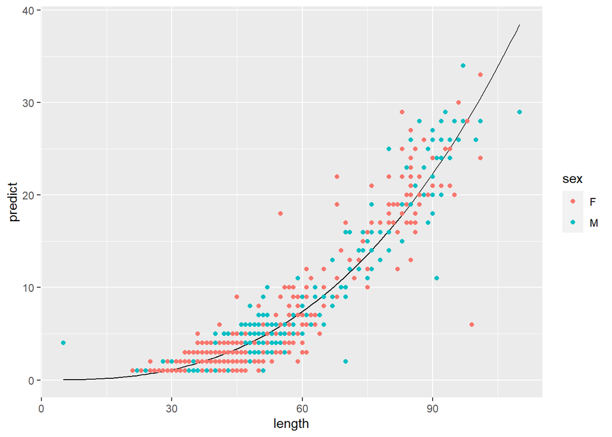

```r
#Create length function model
length_to_weight<-function(a,b,length){
  out=a*length^b

  return(out)
}
# Add controls
controls=nls.control(maxiter=100)

guess_model=lm(log(weight)~log(SV_length),data=lizard_comb)

#Run nls
nls_one<-nls(weight~length_to_weight(a,b,SV_length),
             data=lizard_comb,
             start=list(a=exp(coefficients(guess_model))[1],b=coefficients(guess_model)[2]),
             control=controls)

#Set up the predictions for graphing
length_step<- seq(from=min(lizard_comb$SV_length),to=max(lizard_comb$SV_length),length.out=100)


predictions<-length_to_weight(a=coefficients(nls_one)[1],b=coefficients(nls_one)[2],length_step)


#collect the predictions into one df
dfplot=data.frame(predict=predictions,length=length_step)

# Make a graph
ggplot(dfplot,aes(x=length,y=predict))+
  geom_line(color="black")+
  geom_point(data=lizard_comb,aes(x=SV_length,y=weight,color=sex))
```

3. Present your fitted model on a plot with female and male lizards separated by color. You should include the nls model in `kable` output of the html.

```r
broom::tidy(nls_one) |>
  knitr::kable() |>
  kableExtra::kable_classic_2()
```

| term | estimate | std.error | statistic | p.value |
| --- | --- | --- | --- | --- |
| a | 0.0001073 | 0.0000091 | 11.77374 | 0 |
| b | 2.7209865 | 0.0196796 | 138.26425 | 0 |

**The following parts are super-mega optional! It’s using purrr to run on all species. If you’re craving more continue on. Otherwise you will be asked to do something similar in your homework!**

4. Group by species and sex then nest the data. Use `map()` variants to parameterize length to weight models for every species separated by each sex. Hint: you may need to adjust the controls of the `nls` function

```r
nls_fcn<-function(lizard_df){

  guess_model=lm(log(weight)~log(SV_length),data=lizard_df)

  nls_one<-nls(weight~length_to_weight(a,b,SV_length),
               data=lizard_df,
               start=list(a=exp(coefficients(guess_model)[1]),b=coefficients(guess_model)[2]),control = controls)

  return(nls_one)
}

nls_lizards_purr<-lizard_comb |>
  group_by(spp,sex) |>
  nest() |>
  arrange(spp) |>
  mutate(nls_model=map(data,~nls_fcn(.x))) |>
  mutate(predictions=map2(nls_model,data,~predict(.x,newdata=.y))) |>  #Part 5 here
  mutate(RMSE=map2_dbl(predictions,data,~Metrics::rmse(.x,.y$weight)))
```

5. Use the models to predict the data. Calculate the RMSE for each model created in part 3. Make at table showing the RMSE for each model. Does using a tailored species and sex model out perform using nls on the whole dataset? Write a brief description of when you should use NLS on a whole dataset or subsets.

```r
nls_lizards_purr |>
  select(spp,sex,RMSE) |>
  knitr::kable() |>
  kableExtra::kable_classic_2()
```

| spp | sex | RMSE |
| --- | --- | --- |
| CNIN | F | 1.0846017 |
| CNIN | M | 0.8183036 |
| CNTI | M | 3.3492860 |
| CNTI | F | 3.3563315 |
| COTE | M | 1.1302424 |
| COTE | F | 1.4399634 |
| HOMA | M | 1.0056945 |
| HOMA | F | 1.2784968 |
| PHMO | F | 3.6221218 |
| PHMO | M | 1.5050249 |
| SCUN | F | 1.2993185 |
| SCUN | M | 1.0075811 |
| UTST | F | 0.7765200 |
| UTST | M | 0.8996849 |

6. Create a plot grid showing each species and sexes actual weight and the model prediction.

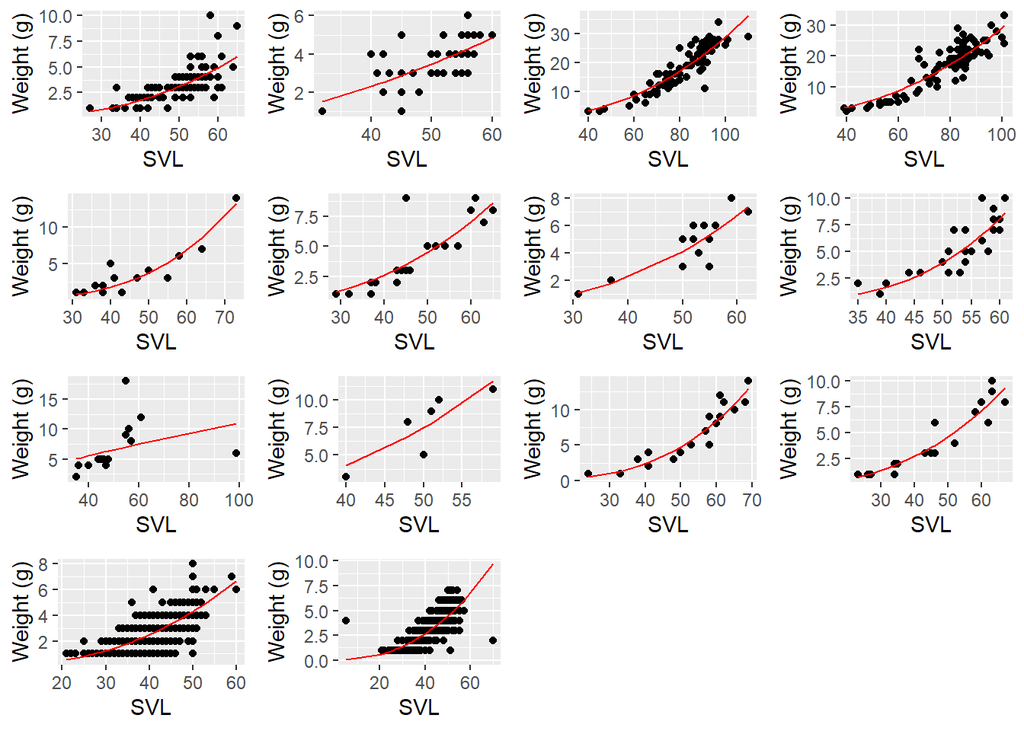

```r
  plts<-nls_lizards_purr |>
  mutate(graph=map2(data,predictions,~ggplot()+
                geom_point(data = .x,aes(x=.x$SV_length,y=.x$weight))+
                geom_line(aes(x=.x$SV_length,y=.y),color='red')+
                  labs(x="SVL",y="Weight (g)")))

library(cowplot)

  plot_grid(plotlist = plts$graph)
```